# Задание банка Открытие

# Подготовка данных

Для начала считаем данные из файла и взглянем на них.

```r
od <- read_excel("OpenRisk.xlsx",
                col_names = c("Bank","Parameter",paste(rep("M",24),1:24,sep = "")),
                skip = 2)
#kable(head(od)[,1:7],digits = 3,align = "c")
#        kable_styling(full_width = TRUE)
head(od)[,1:7]
```

| Bank | Parameter | M1 | M2 | M3 | M4 | M5 |
| --- | --- | --- | --- | --- | --- | --- |
| А | Кол-во принятых кредитных заявок | 7357.1012019 | 1.047682e+04 | 1.054394e+04 | 1.070278e+04 | 7656.7701397 |
| NA | Уровень одобрения | 0.1576522 | 1.571524e-01 | 1.581591e-01 | 1.605418e-01 | 0.1640736 |
| NA | Кол-во выданных кредитов | 890.7747526 | 1.185449e+03 | 1.427483e+03 | 1.580785e+03 | 934.6679990 |
| Б | Кол-во принятых кредитных заявок | 6660.2318842 | 9.544878e+03 | 9.484121e+03 | 9.343363e+03 | 6399.5652352 |
| NA | Уровень одобрения | 0.3678551 | 3.666888e-01 | 3.690379e-01 | 3.745975e-01 | 0.3828385 |
| NA | Кол-во выданных кредитов | 2156.0000000 | 3.276000e+03 | 2.744000e+03 | 2.660000e+03 | 1960.0000000 |

Приведём данные к *чистому* виду. Каждое наблюдение будет в своём ряду, каждый показатель - в своём столбце.

```r
od <- od %>%
        gather(Month, number, M1:M24) %>%
        mutate (Bank = rep(LETTERS[1:5],each = 3,times = 24)) %>%
        spread(`Parameter`, number) %>%
        mutate(Month = parse_number(Month)) %>%
        arrange(Bank,Month) %>%
        select (1,2,Requests = 4,Approval = 5,Issues = 3)
kable(head(od), digits = c(0,0,0,3,0),align = "c")
```

[output not shown]

```r
   #     kable_styling(full_width = TRUE)
```

Данные отсортированы по месяцам внутри каждого отдельного банка. В конце таблицы будут данные за последние месяцы 5 банка, который мы обозначили за **E**.

```r
kable(tail(od),digits = c(0,0,0,3,0),align = "c")
```

[output not shown]

```r
#tail(od)
```

Тут же мы видим, что некоторые данные в таблице отсутствуют. Всего строк с пропущенными значениями в файле 8. Это не так много, поэтому взглянем на них.

```r
kable(od[!complete.cases(od),],align = "c")
```

[output not shown]

```r
#od[!complete.cases(od),]
```

Примечательно, что от банков **D** и **E** нет информации за первые месяцы - возможно, они недавно открылись. Более примечательно, что от банка **E** нет информации за последние месяцы. Возникает предположение, что это отделение закрылось. Посмотрим, есть ли какие-то очевидные поводы для такого решения.

# Изучим данные

Для начала добавим в нашу таблицу столбцы с абсолютным количеством одобренных заявок, а так же “уровень согласия” - то есть процент одобренных заявок, на которые согласились клиенты.

```r
od <- od %>%
        mutate(Approved = Requests*Approval,Acceptance = Issues/Approved) %>%
        select(c(1,2,3,6,5,4,7))
odl <- od %>%
        gather(variable,value,Requests:Acceptance) %>%
        mutate(variable = factor(variable,levels = names(od)[3:7]))
ABS <- names(od)[3:5]
REL <- names(od)[6:7]
kable(head(od),digits = c(0,0,0,0,0,3,3),align = "c")
```

[output not shown]

```r
#od
```

Построим графики абсолютных показателей:

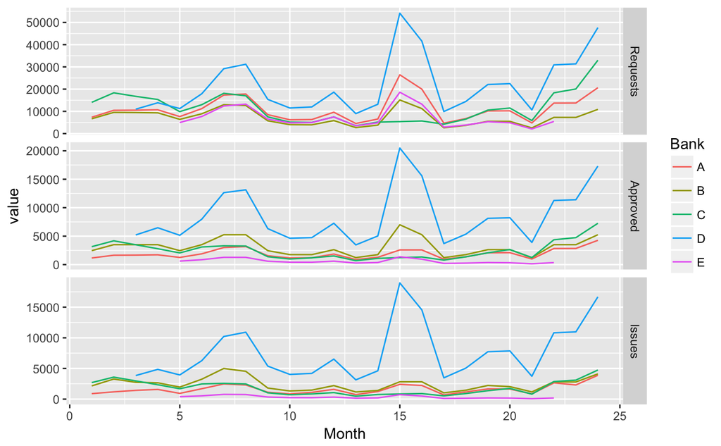

```r
ggplot(filter(odl,variable %in% ABS),
       aes(x = Month, y = value, color = Bank)) +
    geom_line() +
    facet_grid(variable ~ ., scale = "free_y")
```

Действительно, в банк **E** долгое время подавалось наименьшее количество заявок, почти всегда там одобрялось наименьшее количество заявок и всегда там выпускалось наименьшее количество кредитов. Возможно, он находился в районе с малым числом потенциальных клиентов. Так выглядят гистограммы наших абсолютных показателей:

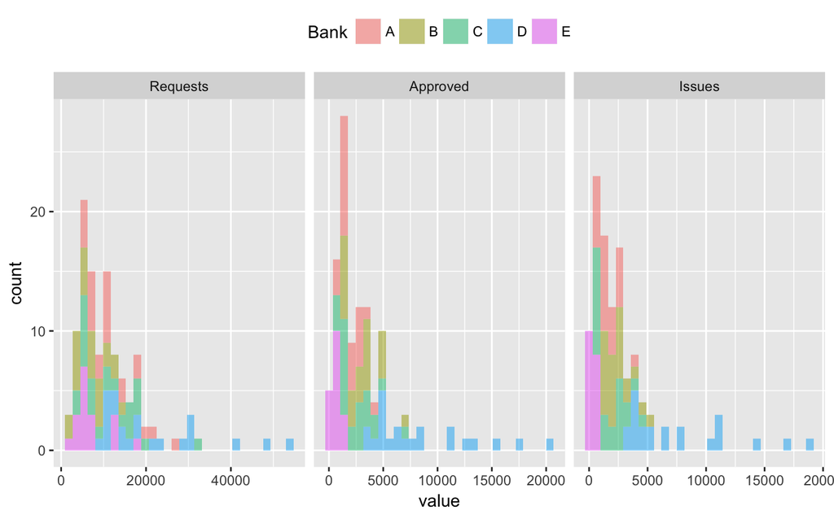

```r
ggplot(filter(odl,variable %in% ABS),
       aes(x = value, fill = Bank)) +
    geom_histogram(alpha = 0.5) +
    facet_grid(. ~ variable, scales = "free_x") +
    theme(legend.position = "top")
```

Видно, что они имеют далеко не нормальное распределение. Простое логарифмирование тоже нормализует слишком грубо:

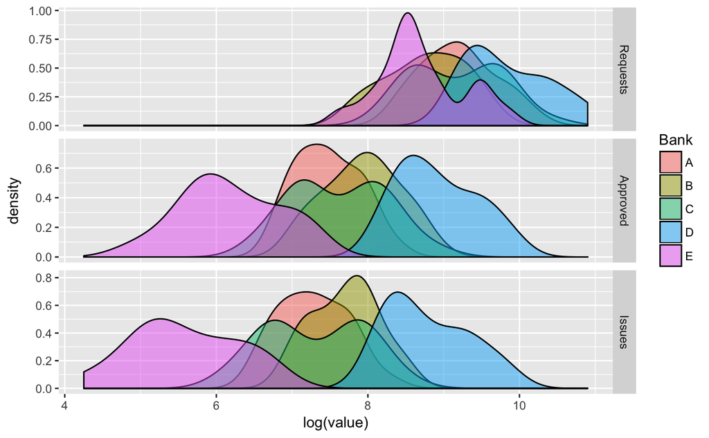

```r
ggplot(filter(odl,variable %in% ABS),
       aes(x = log(value), fill = Bank)) +
    geom_density(alpha = 0.5) +
    facet_grid(variable ~ ., scales = "free_y")
```

Чтобы не нарушать предпосылок таких тестов, как ANOVA и текст Тьюки, воспользуемся непараметрическим тестом Данна, чтобы узнать, в какие банки подавалось статистически больше заявок.

```r
dunn.test(od$Requests,od$Bank,method = "bonferroni")
```

```
  Kruskal-Wallis rank sum test

data: x and group
Kruskal-Wallis chi-squared = 37.0577, df = 4, p-value = 0

                           Comparison of x by group
                                 (Bonferroni)
Col Mean-|
Row Mean |          A          B          C          D
---------+--------------------------------------------
       B |   2.231156
         |     0.1284
       C |  -0.011111  -2.242268
         |     1.0000     0.1247
       D |  -3.063733  -5.245847  -3.052866
         |     0.0109     0.0000     0.0113
       E |   2.366033   0.300383   2.376320   5.166562
         |     0.0899     1.0000     0.0874     0.0000
```

Сильно от всех остальных отличается банк **D**. А ближе всего друг к другу находятся пары **A** и **C**, а так же **B** и **E**. Возможно, другие банки проводили более гибкую кредитную политику.

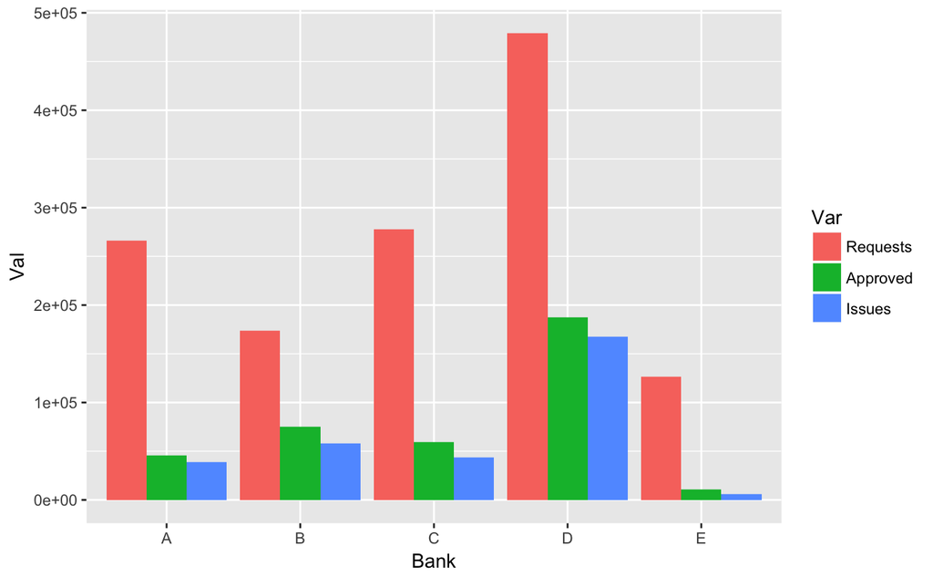

```r
asum <- data.frame(Bank = rep("A",3),Var = ABS, Val = c(sum(od$Requests[od$Bank=="A"]),
                                                            sum(od$Approved[od$Bank=="A"]),
                                                        sum(od$Issues[od$Bank=="A"])))
bsum <- data.frame(Bank = rep("B",3),Var = ABS, Val = c(sum(od$Requests[od$Bank=="B"]),
                                                            sum(od$Approved[od$Bank=="B"]),
                                                        sum(od$Issues[od$Bank=="B"])))
csum <- data.frame(Bank = rep("C",3),Var = ABS, Val = c(sum(od$Requests[od$Bank=="C"]),
                                                            sum(od$Approved[od$Bank=="C"]),
                                                        sum(od$Issues[od$Bank=="C"])))
dsum <- data.frame(Bank = rep("D",3),Var = ABS, Val = c(sum(od$Requests[od$Bank=="D"],
                                                            na.rm = T),
                                                           sum(od$Approved[od$Bank=="D"],
                                                               na.rm = T),
                                                        sum(od$Issues[od$Bank=="D"],
                                                            na.rm = T)))
esum <- data.frame(Bank = rep("E",3),Var = ABS, Val = c(sum(od$Requests[od$Bank=="E"],
                                                            na.rm = T),
                                                            sum(od$Approved[od$Bank=="E"],
                                                                na.rm = T),
                                                        sum(od$Issues[od$Bank=="E"],
                                                            na.rm = T)))
allsum <- rbind(asum,bsum,csum,dsum,esum)
allsum$Var <- factor(allsum$Var,levels = ABS)
ggplot(allsum, aes(Bank, Val)) +
    geom_bar(stat = "identity", aes(fill = Var), position = "dodge")
```

Действительно, в банк **B** за все время было подано немногим больше заявок, чем в банк **E** (то же мы увидели и в результате теста), и меньше, чем в банки **A** и **C**, однако число одобренных и выданных кредитов даже больше последних. Взглянем на относительные уровни одобрения и согласия.

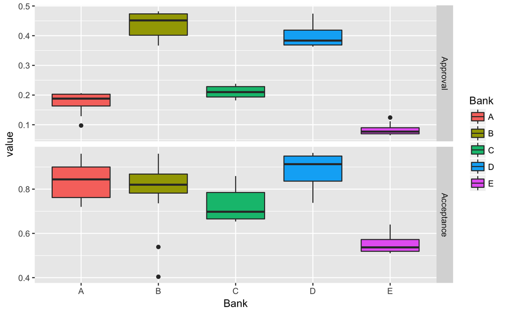

```r
ggplot(filter(odl,variable %in% REL),
       aes(x = Bank, y = value, fill = Bank)) +
    geom_boxplot() +
    facet_grid(variable ~ ., scale = "free_y")
```

В самом деле, банк **B** одобрял в среднем даже больше самого успешного банка **D**. Возможно, последний находится в густонаселенном районе и подобная политика привела к лояльности клиентов к банку, что и стало причиной его успеха. Тогда банку **B** стоит продолжать придерживаться данной стратегии, если это не приводит к росту невыплаченных задолжностей. Продолжим анализ и посмотрим, какие из этих различий статистически значимые.

```r
dunn.test(od$Approval,od$Bank,method = "bonferroni")
```

```
  Kruskal-Wallis rank sum test

data: x and group
Kruskal-Wallis chi-squared = 98.3324, df = 4, p-value = 0

                           Comparison of x by group
                                 (Bonferroni)
Col Mean-|
Row Mean |          A          B          C          D
---------+--------------------------------------------
       B |  -6.475743
         |     0.0000
       C |  -1.666715   4.809028
         |     0.4779     0.0000
       D |  -5.060952   1.272450  -3.430872
         |     0.0000     1.0000     0.0030
       E |   2.464810   8.460184   4.007888   7.118304
         |     0.0685     0.0000     0.0003     0.0000
```

Банки **B** и **D** действительно похожи, а предположительно закрытый банк **E** сильно отличается от всех остальных. Больше всего с ним статистически схож банк **A**.

```r
dunn.test(od$Acceptance,od$Bank,method = "bonferroni")
```

```
  Kruskal-Wallis rank sum test

data: x and group
Kruskal-Wallis chi-squared = 64.0496, df = 4, p-value = 0

                           Comparison of x by group
                                 (Bonferroni)
Col Mean-|
Row Mean |          A          B          C          D
---------+--------------------------------------------
       B |   0.404470
         |     1.0000
       C |   2.997973   2.593502
         |     0.0136     0.0475
       D |  -1.672621  -2.068201  -4.604697
         |     0.4720     0.1931     0.0000
       E |   5.787782   5.413315   3.012198   7.231602
         |     0.0000     0.0000     0.0130     0.0000
```

По уровню согласия на одобренные условия банк **E** уступает всем остальным. Однако и в банке **C** клиенты берут одобренные кредиты статистически меньше, чем в банках **A**,**B** и **D**. Эти замечания являются поводом для пересмотра кредитной политики в банках **A** и **C**. Такая строгость при одобрении может послужить причиной потери лояльности клиентов и повторения судьбы банка **E**.

# Примечание

Так как данные представлены за каждый месяц, было бы полезно проанализировать их, как временные ряды. Возможно, исходя из анализа сезонности, мы смогли бы объяснить эти пики и их разнонаправленность (особенно на 15 месяце):

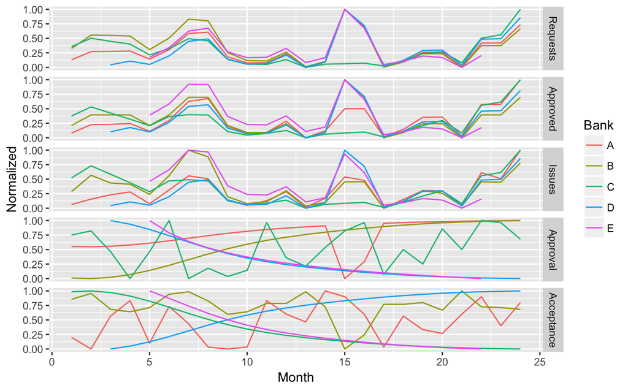

```r
# Normazile to 0-1
normalize <- function(vec) {
    answer <- (vec - min(vec, na.rm = T))/(max(vec, na.rm = T) - min(vec, na.rm = T))
    return(answer)
}
odl$Normalized <- ave(odl$value, odl$Bank, odl$variable, FUN = normalize)
ggplot(odl,
       aes(x = Month, y = Normalized, color = Bank)) +
    geom_line() +
    facet_grid(variable ~ .)
```

Однако, так как в банках **D** и **E** отсутствует информация за несколько месяцев, это представляется бессмысленным, так как нет двух полных периодов.

**Стоит заметить, что этих данных не хватает, чтобы делать никакие выводы. Любая кредитная политика может быть эффективна и нет, её выбор должен происходить из анализа параметров района, макроэкономической ситуации и даже самого банка.**

**Так же было бы интересно сделать попарные сравнения первых и последних 12 месяцев для каждого банка, но у меня уже больше 500 слов.**